```r
library("readxl")
library(corrplot)
library("dplyr")
library(mice, warn.conflicts=FALSE)
library(car)
library(caret)
library(dplyr)
library(cleandata)
```

[Data source](https://archive.ics.uci.edu/dataset/424/csm+conventional+and+social+media+movies+dataset+2014+and+2015)

# 1. EDA

```r
# Load data
data <- read_excel('../data/CSM.xlsx')
head(data)
```

```
## # A tibble: 6 × 14
##   Movie   Year Ratings Genre  Gross Budget Screens Sequel Sentiment  Views Likes
##   <chr>  <dbl>   <dbl> <dbl>  <dbl>  <dbl>   <dbl>  <dbl>     <dbl>  <dbl> <dbl>
## 1 13 Si…  2014     6.3     8 9.13e3 4   e6      45      1         0 3.28e6  4632
## 2 22 Ju…  2014     7.1     1 1.92e8 5   e7    3306      2         2 5.83e5  3465
## 3 3 Day…  2014     6.2     1 3.07e7 2.8 e7    2872      1         0 3.05e5   328
## 4 300: …  2014     6.3     1 1.06e8 1.10e8    3470      2         0 4.53e5  2429
## 5 A Hau…  2014     4.7     8 1.73e7 3.5 e6    2310      2         0 3.15e6 12163
## 6 A Lon…  2014     4.6     3 2.90e4 5   e5      NA      1         0 9.11e4   112
## # ℹ 3 more variables: Dislikes <dbl>, Comments <dbl>,
## #   `Aggregate Followers` <dbl>
```

```r
# Rename columns
colnames(data) = c("Movie", "Year", "Ratings", "Genre", "Gross", "Budget", "Screens", "Sequel", "Sentiment",
                   "Views", "Likes", "Dislikes", "Comments", "Aggregate_Followers")
```

```r
# data shape
nrow(data)
```

```
## [1] 231
```

```r
length(colnames(data))
```

```
## [1] 14
```

```r
# check the duplicated rows
nrow(unique(data))
```

```
## [1] 231
```

The data shape does not change after de-duplicating, so there are no duplicated rows in the dataset

```r
# Check data type
str(data)
```

```
## tibble [231 × 14] (S3: tbl_df/tbl/data.frame)
##  $ Movie              : chr [1:231] "13 Sins" "22 Jump Street" "3 Days to Kill" "300: Rise of an Empire" ...
##  $ Year               : num [1:231] 2014 2014 2014 2014 2014 ...
##  $ Ratings            : num [1:231] 6.3 7.1 6.2 6.3 4.7 4.6 6.1 7.1 6.5 6.1 ...
##  $ Genre              : num [1:231] 8 1 1 1 8 3 8 1 10 8 ...
##  $ Gross              : num [1:231] 9.13e+03 1.92e+08 3.07e+07 1.06e+08 1.73e+07 2.90e+04 4.26e+07 5.75e+06 2.60e+07 4.86e+07 ...
##  $ Budget             : num [1:231] 4.00e+06 5.00e+07 2.80e+07 1.10e+08 3.50e+06 5.00e+05 4.00e+07 2.00e+07 2.80e+07 1.25e+07 ...
##  $ Screens            : num [1:231] 45 3306 2872 3470 2310 ...
##  $ Sequel             : num [1:231] 1 2 1 2 2 1 1 1 1 1 ...
##  $ Sentiment          : num [1:231] 0 2 0 0 0 0 0 2 3 0 ...
##  $ Views              : num [1:231] 3280543 583289 304861 452917 3145573 ...
##  $ Likes              : num [1:231] 4632 3465 328 2429 12163 ...
##  $ Dislikes           : num [1:231] 425 61 34 132 610 7 419 197 419 532 ...
##  $ Comments           : num [1:231] 636 186 47 590 1082 ...
##  $ Aggregate_Followers: num [1:231] 1120000 12350000 483000 568000 1923800 ...
```

Comment:

The dataset contains both quantitative and qualitative variables: The qualitative variables: Genre, Sequel, Sentiment The quantitative variables: The remains

We will exclude “Movie” and “Year” from model because they do not contribute to prediction.

```r
data <- data[, c('Ratings', 'Genre', 'Gross', 'Budget', 'Screens', 'Sequel', 'Sentiment', 'Views', 'Likes', 'Dislikes', 'Comments', 'Aggregate_Followers')]
```

Encoding qualitative variables:

```r
unique(data$Genre)
```

```
##  [1]  8  1  3 10 15 12  9  2  7  6  4
```

```r
unique(data$Sequel)
```

```
## [1] 1 2 3 5 6 4 7
```

```r
unique(data$Sentiment)
```

```
##  [1]   0   2   3   4  29  -1  -2   9   5  -4   1   6 -11  -9  14  10  -5  27  13
## [20]   8   7  17  20  -3  11  -6  21 -17  15  -8  19  16 -38  25  18  26
```

Because Sequel and Sentiment is ordinal, we will apply Ordinal Encoding method for them. For Genre, we apply Dummy variables method.

```r
data$Genre = relevel(as.factor(data$Genre), ref=1)
```

```r
contrasts(data$Genre)
```

```
##    2 3 4 6 7 8 9 10 12 15
## 1  0 0 0 0 0 0 0  0  0  0
## 2  1 0 0 0 0 0 0  0  0  0
## 3  0 1 0 0 0 0 0  0  0  0
## 4  0 0 1 0 0 0 0  0  0  0
## 6  0 0 0 1 0 0 0  0  0  0
## 7  0 0 0 0 1 0 0  0  0  0
## 8  0 0 0 0 0 1 0  0  0  0
## 9  0 0 0 0 0 0 1  0  0  0
## 10 0 0 0 0 0 0 0  1  0  0
## 12 0 0 0 0 0 0 0  0  1  0
## 15 0 0 0 0 0 0 0  0  0  1
```

```r
data$Sentiment <- as.ordered(data$Sentiment)
data$Sequel <- as.ordered(data$Sequel)
```

# Check missing values (null values)

```r
colSums(is.na(data))/nrow(data)
```

```
##             Ratings               Genre               Gross              Budget
##         0.000000000         0.000000000         0.000000000         0.004329004
##             Screens              Sequel           Sentiment               Views
##         0.043290043         0.000000000         0.000000000         0.000000000
##               Likes            Dislikes            Comments Aggregate_Followers
##         0.000000000         0.000000000         0.000000000         0.151515152
```

15%, 4.3%, 0.43% is the missing percentage of of Aggregate_Followers, Screens and Budget respectively

## Missing data pattern

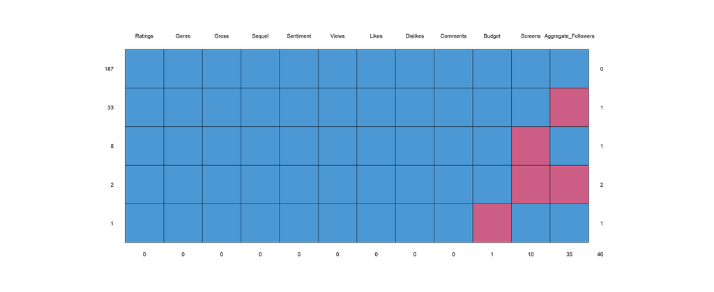

```
##     Ratings Genre Gross Sequel Sentiment Views Likes Dislikes Comments Budget
## 187       1     1     1      1         1     1     1        1        1      1
## 33        1     1     1      1         1     1     1        1        1      1
## 8         1     1     1      1         1     1     1        1        1      1
## 2         1     1     1      1         1     1     1        1        1      1
## 1         1     1     1      1         1     1     1        1        1      0
##           0     0     0      0         0     0     0        0        0      1
##     Screens Aggregate_Followers
## 187       1                   1  0
## 33        1                   0  1
## 8         0                   1  1
## 2         0                   0  2
## 1         1                   1  1
##          10                  35 46
```

```r
md.pattern(data)
```

Comment:

- There are 187 (~80.95%) observations that are totally completed (no missing value in any column)
- There are 33 (~14.28%) observations that have missing values at only column Aggregate Followers
- There are 8 (~3.46%) observations that have missing values at only column Screens
- There are 2 (~0.86%) observations that have missing values at both Aggregate_Followers and cột Screens
- There is only 1 (~0.43%) observation that have missing value at only column Budget

Most data is missed in only 1 column.

The null percentage of Budget is very small (only 0.43%) so that we will remove this record from the dataset. For the Screens and Aggregate_Followers, we will fill missing data using “mice” algorithm

```r
# Remove 1 missing value at Budget
data <- subset(data, is.na(data$Budget) == FALSE)
```

```r
# "mice" algorithm using "cart" method
imp <- mice(data, method='cart', seed=123)
data_cpt <- complete(imp)
```

Compare mean before and after fill null, check whether their mean comes from same distribution or not.

Hypothesis: H0: mu_before = mu_after H1: mu_before!= mu_after

Choose anpha = 0.05

```r
# t-test for Screens
t.test(data$Screens, data_cpt$Screens)
```

```
##
##  Welch Two Sample t-test
##
## data:  data$Screens and data_cpt$Screens
## t = 0.46417, df = 447.6, p-value = 0.6427
## alternative hypothesis: true difference in means is not equal to 0
## 95 percent confidence interval:
##  -208.4648  337.3885
## sample estimates:
## mean of x mean of y
##  2217.323  2152.861
```

With p-value = 0.6427, There is not enough clue to reject H0 => Conclusion: The mean of Screens before filled null and after filled null is the same.

```r
# t-test for Aggregate_Followers
t.test(data$Aggregate_Followers, data_cpt$Aggregate_Followers)
```

```
##
##  Welch Two Sample t-test
##
## data:  data$Aggregate_Followers and data_cpt$Aggregate_Followers
## t = 0.3243, df = 404.29, p-value = 0.7459
## alternative hypothesis: true difference in means is not equal to 0
## 95 percent confidence interval:
##  -765179.1 1067512.9
## sample estimates:
## mean of x mean of y
##   3049579   2898412
```

With p-value = 0.7459, There is not enough clue to reject H0 => Conclusion: The mean of Aggregate_Followers before filled null and after filled null is the same.

## Check the correlative between quantitative variables:

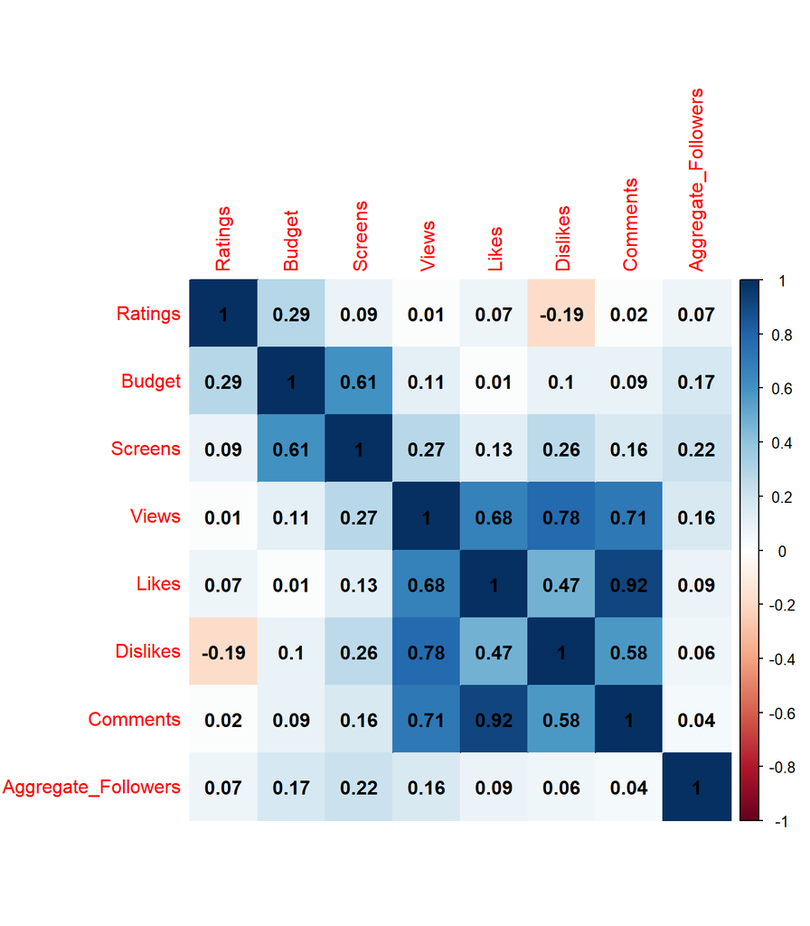

```r
numeric_cols = c('Ratings', 'Budget', 'Screens', 'Views', 'Likes', 'Dislikes', 'Comments', 'Aggregate_Followers')
corrplot(cor(data_cpt[,numeric_cols]), addCoef.col = 'black', method="color")
```

With threshold 0.8, there is the high correlation between Comments and Likes. We will handle it later

# Check the distribution of quantitative variables:

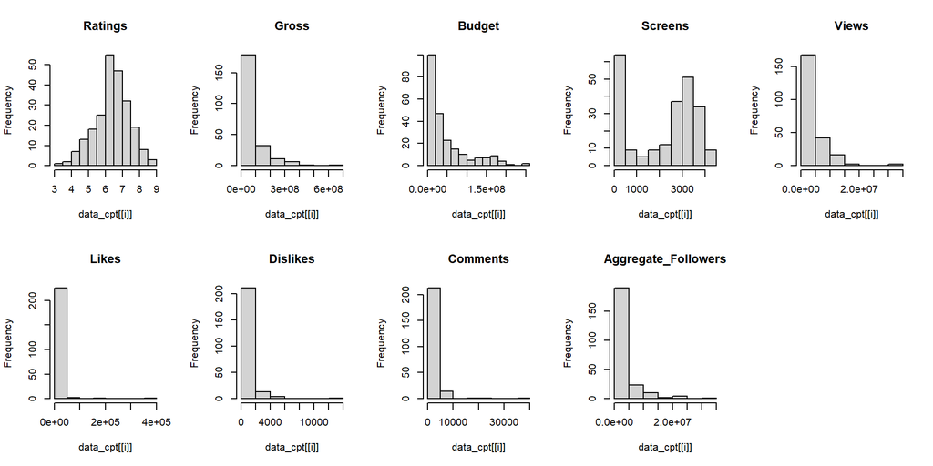

```r
numeric_cols = c('Ratings', 'Gross', 'Budget', 'Screens', 'Views', 'Likes', 'Dislikes', 'Comments', 'Aggregate_Followers')
par(mfrow=c(2, 5))
for (i in numeric_cols){
  hist(data_cpt[[i]], main=i)
}
```

Gross is high skew (not normal). In linear regression model, we assume that dependence variable have normal shape, so that we will apply Box-Cox transformation for Gross, which will change Gross’s distribution to approximatetly normal. Besides, the range of variables is different => need to be scaled.

```r
bc_trans <- BoxCoxTrans(data_cpt$Gross)
data_cpt$Gross <- predict(bc_trans, data_cpt$Gross)
```

```r
shapiro.test(data_cpt$Gross)
```

```
##
##  Shapiro-Wilk normality test
##
## data:  data_cpt$Gross
## W = 0.98227, p-value = 0.005597
```

```r
lambda <- bc_trans$lambda
lambda
```

```
## [1] 0.3
```

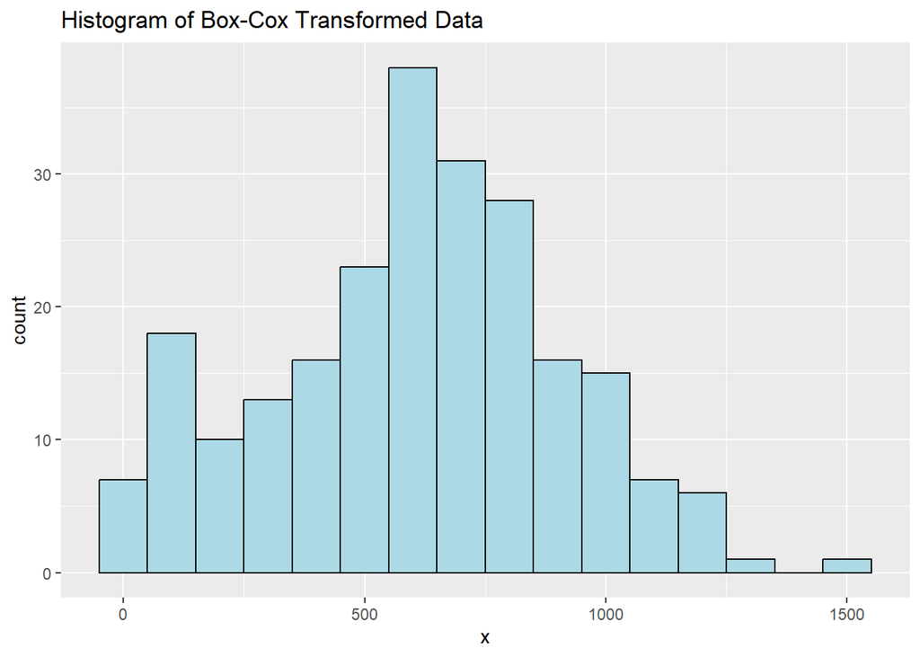

```r
par(mfrow=c(1, 2))
ggplot(data.frame(x = data_cpt$Gross), aes(x)) +
  geom_histogram(binwidth = 100, color = "black", fill = "lightblue") +
  ggtitle("Histogram of Box-Cox Transformed Data")
```

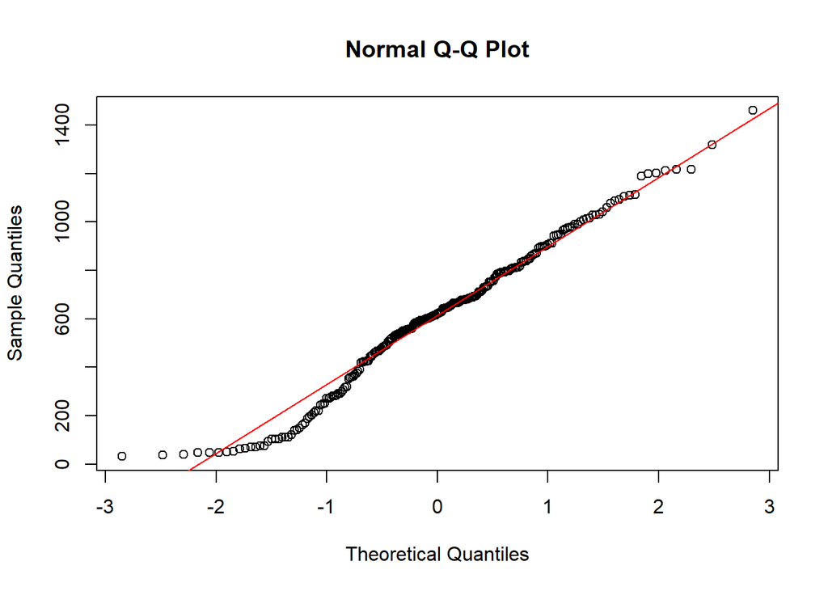

```r
qqnorm(data_cpt$Gross)
qqline(data_cpt$Gross, col = "red")
```

Scale data (mean = 0 and std = 1):

```r
std <- sd(data_cpt$Gross)
mu <- mean(data_cpt$Gross)
```

```r
numeric_cols = c('Ratings', 'Gross', 'Budget', 'Screens', 'Views', 'Likes', 'Dislikes', 'Comments', 'Aggregate_Followers')
for (i in numeric_cols){
  data_cpt[[i]] <- scale(data_cpt[[i]])
}
```

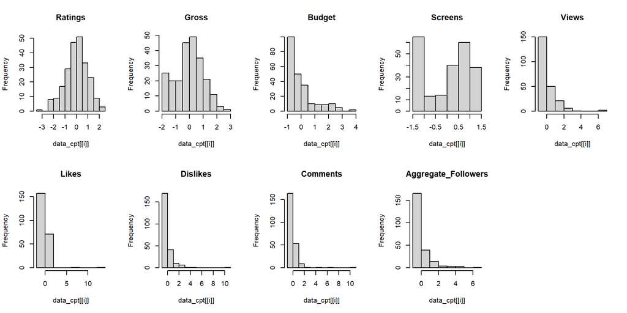

```r
numeric_cols = c('Ratings', 'Gross', 'Budget', 'Screens', 'Views', 'Likes', 'Dislikes', 'Comments', 'Aggregate_Followers')
par(mfrow=c(2, 5))
for (i in numeric_cols){
  hist(data_cpt[[i]], main=i)
}
```

# Check outliers data

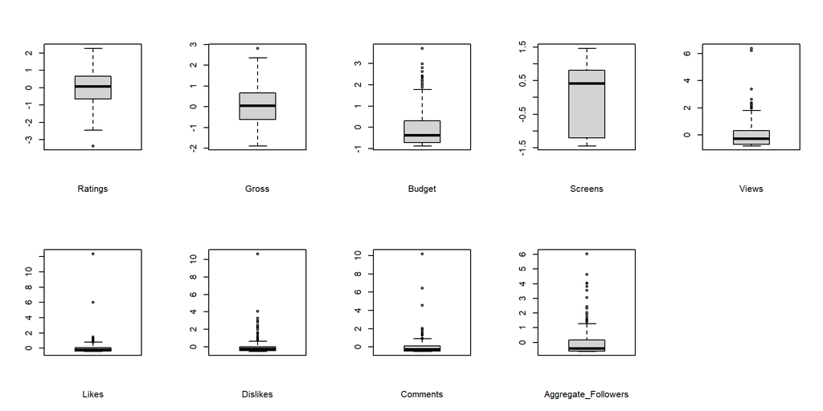

```r
numeric_cols = c('Ratings', 'Gross', 'Budget', 'Screens', 'Views', 'Likes', 'Dislikes', 'Comments', 'Aggregate_Followers')
par(mfrow=c(2, 5))
for (i in numeric_cols){
  boxplot(data_cpt[[i]], xlab=i)
}
```

Except for Screens, outliers appear in all remaining variables.

# Detect outlier for multivariate variables using mahalanobis distance

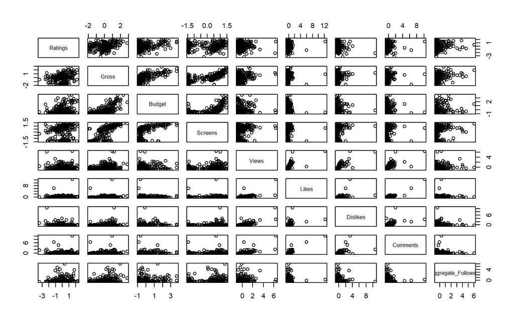

```r
pairs(data_cpt[,numeric_cols])
```

```r
MD <- mahalanobis(data_cpt[, numeric_cols], colMeans(data_cpt[, numeric_cols]), cov(data_cpt[, numeric_cols]), inverted=TRUE)
```

```r
data_cpt$MD <- MD
```

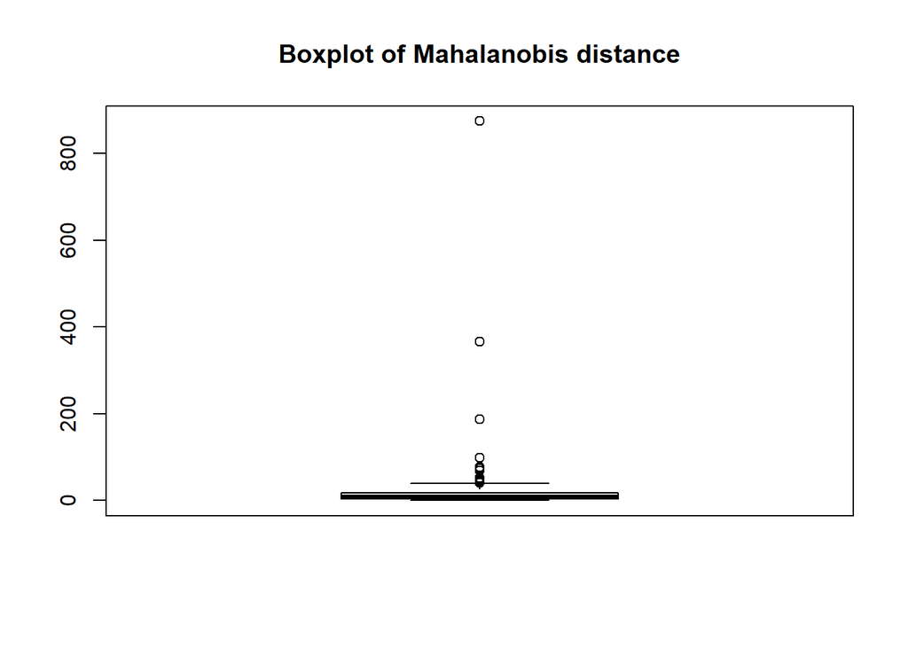

```r
boxplot(MD, main='Boxplot of Mahalanobis distance')
```

```r
quartiles <- quantile(data_cpt$MD, probs=c(.25, .75))
IQR <- IQR(data_cpt$MD)
Lower <- quartiles[1] - 1.5*IQR
Upper <- quartiles[2] + 1.5*IQR
```

```r
exclude_data <- subset(data_cpt, data_cpt$MD <= Lower | data_cpt$MD >= Upper)
mean(exclude_data$MD)
```

```
## [1] 147.6015
```

```r
data_cpt <- data_cpt %>% mutate(Group = case_when(MD > Lower & MD < Upper ~ 1,
                                       MD <= Lower | MD >= Upper ~ 2))
head(data_cpt)
```

```
##      Ratings Genre       Gross      Budget    Screens Sequel Sentiment
## 1 -0.1405030     8 -1.84425928 -0.80904677 -1.4208910      1         0
## 2  0.6673890     1  1.35083966  0.03828213  0.7773212      2         2
## 3 -0.2414895     1 -0.07265514 -0.36696212  0.4847655      1         0
## 4 -0.1405030     1  0.80154421  1.14349375  0.8878722      2         0
## 5 -1.7562869     8 -0.37955875 -0.81825687  0.1059261      2         0
## 6 -1.8572734     3 -1.77385928 -0.87351745 -1.4458323      1         0
##         Views       Likes    Dislikes   Comments Aggregate_Followers        MD
## 1 -0.09932999 -0.28244436 -0.20628759 -0.3348352          -0.3817871 16.580817
## 2 -0.69682236 -0.32285847 -0.49846146 -0.4606464           2.0290538 12.490069
## 3 -0.75849939 -0.43149521 -0.52013370 -0.4995081          -0.5185373  4.233113
## 4 -0.72570221 -0.35873595 -0.44147150 -0.3476959          -0.5002897  6.906940
## 5 -0.12922838 -0.02164002 -0.05779263 -0.2101424          -0.2092284  5.818721
## 6 -0.80584326 -0.43897545 -0.54180593 -0.5123688          -0.5556767 29.609761
##   Group
## 1     1
## 2     1
## 3     1
## 4     1
## 5     1
## 6     1
```

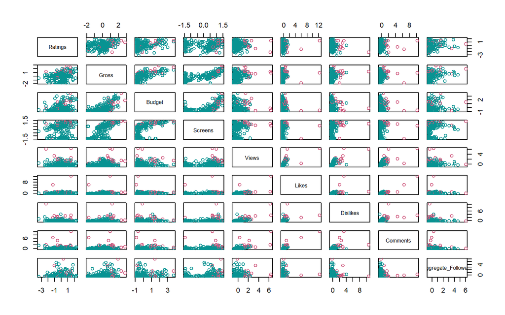

```r
numeric_cols = c('Ratings', 'Gross', 'Budget', 'Screens', 'Views', 'Likes', 'Dislikes', 'Comments', 'Aggregate_Followers')
Group <- data_cpt[, c('Group')]
l <- length(unique(Group))
pairs(data_cpt[,numeric_cols], bg = hcl.colors(l, "Temps")[Group], col = hcl.colors(l, "Temps")[Group])
```

Note: Red color represents for outlier points and will be remove from dataset, green color represents for the normal point.

```r
data_new <- subset(data_cpt, data_cpt$MD > Lower & data_cpt$MD < Upper)
```

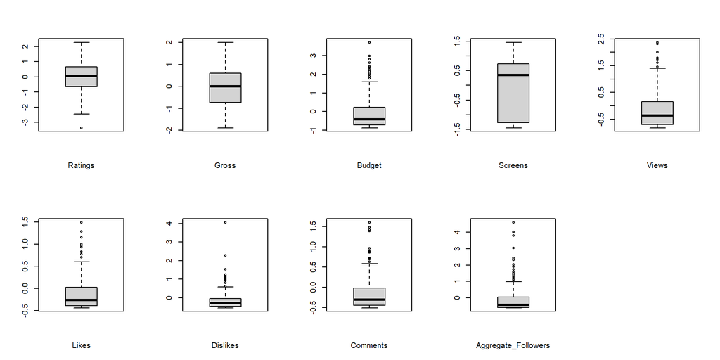

```r
numeric_cols = c('Ratings', 'Gross', 'Budget', 'Screens', 'Views', 'Likes', 'Dislikes', 'Comments', 'Aggregate_Followers')
par(mfrow=c(2, 5))
for (i in numeric_cols){
  boxplot(data_new[[i]], xlab=i)
}
```

```r
nrow(data_cpt)
```

```
## [1] 230
```

```r
nrow(data_new)
```

```
## [1] 216
```

Only 6% data is removed.

```r
str(data_new)
```

```
## 'data.frame':    216 obs. of  14 variables:
##  $ Ratings            : num [1:216, 1] -0.141 0.667 -0.241 -0.141 -1.756 ...
##  $ Genre              : Factor w/ 11 levels "1","2","3","4",..: 7 1 1 1 7 3 7 1 9 7 ...
##  $ Gross              : num [1:216, 1] -1.8443 1.3508 -0.0727 0.8015 -0.3796 ...
##  $ Budget             : num [1:216, 1] -0.809 0.0383 -0.367 1.1435 -0.8183 ...
##  $ Screens            : num [1:216, 1] -1.421 0.777 0.485 0.888 0.106 ...
##  $ Sequel             : Ord.factor w/ 7 levels "1"<"2"<"3"<"4"<..: 1 2 1 2 2 1 1 1 1 1 ...
##  $ Sentiment          : Ord.factor w/ 36 levels "-38"<"-17"<"-11"<..: 12 14 12 12 12 12 12 14 15 12 ...
##  $ Views              : num [1:216, 1] -0.0993 -0.6968 -0.7585 -0.7257 -0.1292 ...
##  $ Likes              : num [1:216, 1] -0.2824 -0.3229 -0.4315 -0.3587 -0.0216 ...
##  $ Dislikes           : num [1:216, 1] -0.2063 -0.4985 -0.5201 -0.4415 -0.0578 ...
##  $ Comments           : num [1:216, 1] -0.335 -0.461 -0.5 -0.348 -0.21 ...
##  $ Aggregate_Followers: num [1:216, 1] -0.382 2.029 -0.519 -0.5 -0.209 ...
##  $ MD                 : num  16.58 12.49 4.23 6.91 5.82 ...
##  $ Group              : num  1 1 1 1 1 1 1 1 1 1 ...
```

# Build model for prediction

- Train test split:

```r
# Split train-test data
set.seed(123)
training.samples <- data_new$Gross  %>%  createDataPartition(p = 0.8, list = FALSE)
train.data  <- data_new[training.samples, ]
test.data <- data_new[-training.samples, ]
dim(train.data)
```

```
## [1] 176  14
```

```r
dim(test.data)
```

```
## [1] 40 14
```

Build model to remove high correlation variables that cause “multicollinearity”

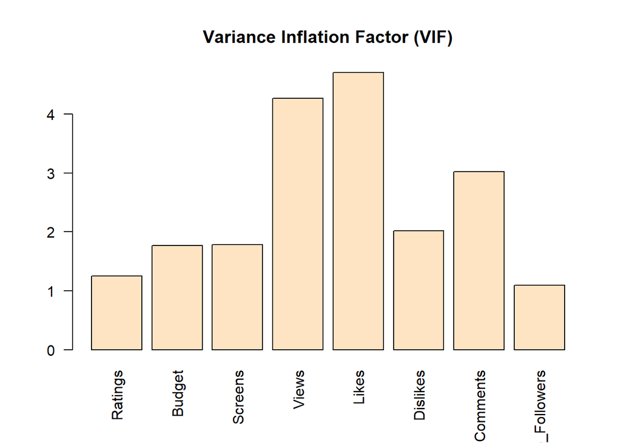

```r
df <- train.data[,c("Ratings", "Gross", "Budget", "Screens", "Views", "Likes",
                    "Dislikes", "Comments", "Aggregate_Followers")]
model_1 <- lm(Gross~., data=df)
vif_model_1 <- vif(model_1)
barplot(vif_model_1, col = "bisque1", main = "Variance Inflation Factor (VIF)",
        las = 2, cex.names = 1)
```

```r
data.frame(vif_model_1)
```

```
##                     vif_model_1
## Ratings                1.251399
## Budget                 1.766553
## Screens                1.779138
## Views                  4.264623
## Likes                  4.704144
## Dislikes               2.020268
## Comments               3.022777
## Aggregate_Followers    1.094226
```

The highest VIF is “Likes” (4.7, approximate 5) so that we will remove it from model

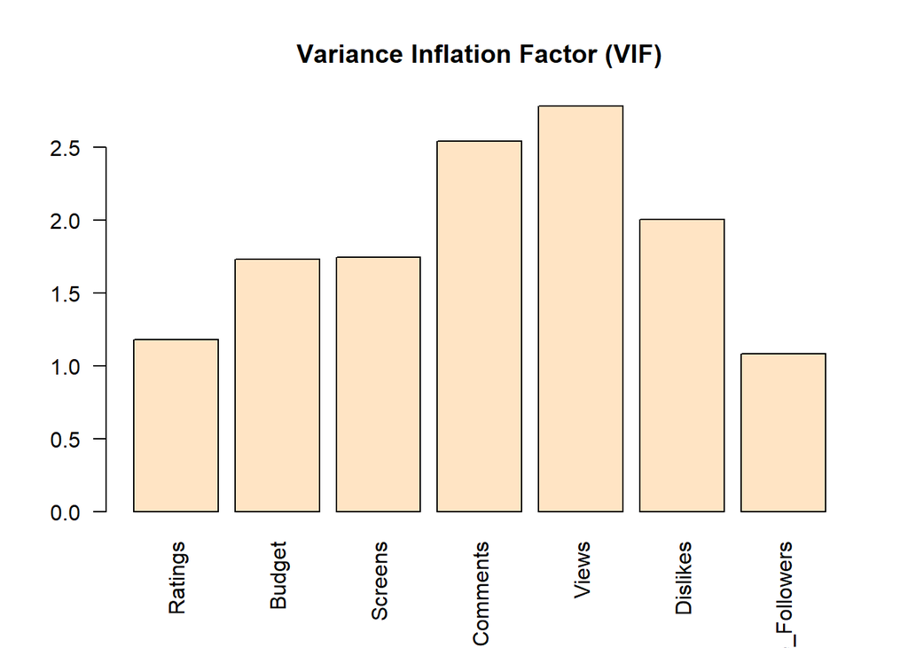

```r
model_2 <- lm(Gross~., data=df[, c("Ratings", "Gross", "Budget", "Screens",
                                   "Comments", "Views", "Dislikes", "Aggregate_Followers")])
vif_model_2 <- vif(model_2)
barplot(vif_model_2, col = "bisque1", main = "Variance Inflation Factor (VIF)",
        las = 2, cex.names = 1)
```

```r
data.frame(vif_model_2)
```

```
##                     vif_model_2
## Ratings                1.182061
## Budget                 1.730297
## Screens                1.746523
## Comments               2.544454
## Views                  2.785369
## Dislikes               2.006674
## Aggregate_Followers    1.085412
```

After remove “Likes”, the remains variables have quite low VIF, we will keep it.

```r
# Build linear regression model
train.data <- train.data[, c("Ratings", "Gross", "Budget", "Screens", "Comments",
                             "Views", "Dislikes", "Aggregate_Followers", 'Genre',
                             'Sequel', 'Sentiment')]
full_model <- lm(Gross~., data=train.data)
summary(full_model)
```

```
##
## Call:
## lm(formula = Gross ~ ., data = train.data)
##
## Residuals:
##      Min       1Q   Median       3Q      Max
## -1.57753 -0.25952 -0.00299  0.26082  1.66899
##
## Coefficients:
##                     Estimate Std. Error t value Pr(>|t|)
## (Intercept)          0.36330    0.20998   1.730  0.08616 .
## Ratings              0.20353    0.06323   3.219  0.00165 **
## Budget               0.14222    0.07931   1.793  0.07545 .
## Screens              0.47827    0.06598   7.249 4.32e-11 ***
## Comments             0.10734    0.19691   0.545  0.58668
## Views               -0.03065    0.11963  -0.256  0.79824
## Dislikes             0.04954    0.14774   0.335  0.73798
## Aggregate_Followers  0.06386    0.05724   1.116  0.26676
## Genre2              -0.15189    0.25383  -0.598  0.55071
## Genre3              -0.44884    0.15991  -2.807  0.00583 **
## Genre4              -1.03023    0.68857  -1.496  0.13721
## Genre6              -0.91911    0.45241  -2.032  0.04439 *
## Genre7              -1.18425    0.43515  -2.721  0.00746 **
## Genre8              -0.17878    0.16116  -1.109  0.26950
## Genre9              -0.25376    0.24387  -1.041  0.30015
## Genre10             -0.23784    0.23942  -0.993  0.32249
## Genre12              0.01133    0.23314   0.049  0.96131
## Genre15             -0.24064    0.28509  -0.844  0.40029
## Sequel.L             0.09449    0.48926   0.193  0.84717
## Sequel.Q             0.33816    0.46150   0.733  0.46514
## Sequel.C             0.29624    0.41161   0.720  0.47309
## Sequel^4            -0.77086    0.53023  -1.454  0.14858
## Sequel^5            -0.42078    0.39765  -1.058  0.29209
## Sequel^6             0.28077    0.52598   0.534  0.59445
## Sentiment.L         -0.59345    0.55679  -1.066  0.28862
## Sentiment.Q          0.53792    0.52137   1.032  0.30425
## Sentiment.C         -0.47966    0.54130  -0.886  0.37730
## Sentiment^4         -0.06776    0.55885  -0.121  0.90370
## Sentiment^5          0.28832    0.52842   0.546  0.58633
## Sentiment^6          0.19449    0.51506   0.378  0.70639
```

[output cut: 16 more lines]

```
## Sentiment^23         0.60092    0.43736   1.374  0.17199
## Sentiment^24         0.75363    0.43383   1.737  0.08491 .
## Sentiment^25         0.05432    0.38893   0.140  0.88917
## Sentiment^26        -0.24835    0.38909  -0.638  0.52450
## Sentiment^27         0.38760    0.32927   1.177  0.24144
## Sentiment^28         0.07112    0.24739   0.288  0.77422
## Sentiment^29         0.19299    0.30804   0.627  0.53216
## Sentiment^30         0.09926    0.30950   0.321  0.74897
## Sentiment^31        -0.03437    0.31365  -0.110  0.91291
## ---
## Signif. codes:  0 '***' 0.001 '**' 0.01 '*' 0.05 '.' 0.1 ' ' 1
##
## Residual standard error: 0.5681 on 121 degrees of freedom
## Multiple R-squared:  0.7525, Adjusted R-squared:  0.642
## F-statistic: 6.812 on 54 and 121 DF,  p-value: < 2.2e-16
```

```r
# choose the best model using step wise method
step(full_model, direction = 'backward', trace = TRUE)
```

```
## Start:  AIC=-155
## Gross ~ Ratings + Budget + Screens + Comments + Views + Dislikes +
##     Aggregate_Followers + Genre + Sequel + Sentiment
##
##                       Df Sum of Sq    RSS      AIC
## - Sentiment           31    6.8872 45.936 -188.410
## - Views                1    0.0212 39.070 -156.903
## - Dislikes             1    0.0363 39.085 -156.835
## - Comments             1    0.0959 39.145 -156.567
## - Aggregate_Followers  1    0.4017 39.450 -155.197
## <none>                             39.049 -154.999
## - Sequel               6    2.8304 41.879 -154.683
## - Budget               1    1.0377 40.086 -152.383
## - Genre               10    5.8185 44.867 -150.553
## - Ratings              1    3.3434 42.392 -142.540
## - Screens              1   16.9566 56.005  -93.526
##
## Step:  AIC=-188.41
## Gross ~ Ratings + Budget + Screens + Comments + Views + Dislikes +
##     Aggregate_Followers + Genre + Sequel
##
##                       Df Sum of Sq    RSS     AIC
## - Sequel               6    2.2734 48.209 -191.91
## - Genre               10    4.9579 50.894 -190.37
## - Dislikes             1    0.0884 46.024 -190.07
## - Views                1    0.1080 46.044 -190.00
## - Comments             1    0.3097 46.246 -189.23
## <none>                             45.936 -188.41
## - Aggregate_Followers  1    1.2065 47.142 -185.85
## - Budget               1    1.4774 47.413 -184.84
## - Ratings              1    5.0738 51.010 -171.97
## - Screens              1   19.5398 65.476 -128.03
##
## Step:  AIC=-191.91
## Gross ~ Ratings + Budget + Screens + Comments + Views + Dislikes +
##     Aggregate_Followers + Genre
##
##                       Df Sum of Sq    RSS     AIC
## - Genre               10    5.1897 53.399 -193.91
## - Views                1    0.0703 48.280 -193.65
```

[output cut: 29 more lines]

```
## - Aggregate_Followers  1    2.4320 55.927 -189.77
## - Budget               1    5.3970 58.892 -180.68
## - Ratings              1    6.1932 59.688 -178.32
## - Screens              1   25.1446 78.639 -129.79
##
## Step:  AIC=-197.19
## Gross ~ Ratings + Budget + Screens + Dislikes + Aggregate_Followers
##
##                       Df Sum of Sq    RSS     AIC
## <none>                             53.619 -197.19
## - Dislikes             1    0.8425 54.461 -196.45
## - Aggregate_Followers  1    2.4018 56.021 -191.48
## - Budget               1    5.4828 59.102 -182.06
## - Ratings              1    6.4188 60.037 -179.29
## - Screens              1   25.2355 78.854 -131.31
```

```
##
## Call:
## lm(formula = Gross ~ Ratings + Budget + Screens + Dislikes +
##     Aggregate_Followers, data = train.data)
##
## Coefficients:
##         (Intercept)              Ratings               Budget
##           -0.000409             0.207183             0.244486
##             Screens             Dislikes  Aggregate_Followers
##            0.505028             0.136308             0.127448
```

The best model (lowest AIC) is: Gross ~ Ratings + Budget + Screens + Dislikes + Aggregate_Followers

```r
model_re = lm(Gross~., data=train.data[,c('Gross', 'Ratings', 'Budget', 'Screens', 'Aggregate_Followers', 'Dislikes')])
summary(model_re)
```

```
##
## Call:
## lm(formula = Gross ~ ., data = train.data[, c("Gross", "Ratings",
##     "Budget", "Screens", "Aggregate_Followers", "Dislikes")])
##
## Residuals:
##      Min       1Q   Median       3Q      Max
## -1.97582 -0.38898 -0.02756  0.36164  1.59029
##
## Coefficients:
##                      Estimate Std. Error t value Pr(>|t|)
## (Intercept)         -0.000409   0.043842  -0.009  0.99257
## Ratings              0.207183   0.045926   4.511 1.20e-05 ***
## Budget               0.244486   0.058639   4.169 4.86e-05 ***
## Screens              0.505028   0.056460   8.945 6.17e-16 ***
## Aggregate_Followers  0.127447   0.046184   2.760  0.00642 **
## Dislikes             0.136308   0.083400   1.634  0.10403
## ---
## Signif. codes:  0 '***' 0.001 '**' 0.01 '*' 0.05 '.' 0.1 ' ' 1
##
## Residual standard error: 0.5616 on 170 degrees of freedom
## Multiple R-squared:  0.6601, Adjusted R-squared:  0.6501
## F-statistic: 66.04 on 5 and 170 DF,  p-value: < 2.2e-16
```

The “Dislike” seems to have no effect to the change of “Gross” (p-value = 0.10403 > 0.05). Let’s build other model without “Dislike”. Hypothesis: H0: Accept shorten model (excluded “Dislike”) H1: Accept full model (included “Dislike”)

```r
model_re_2 <- lm(Gross~., data=train.data[,c('Gross', 'Ratings', 'Budget', 'Screens', 'Aggregate_Followers')])
anova(model_re, model_re_2)
```

```
## Analysis of Variance Table
##
## Model 1: Gross ~ Ratings + Budget + Screens + Aggregate_Followers + Dislikes
## Model 2: Gross ~ Ratings + Budget + Screens + Aggregate_Followers
##   Res.Df    RSS Df Sum of Sq      F Pr(>F)
## 1    170 53.619
## 2    171 54.461 -1  -0.84251 2.6712  0.104
```

p-value = 0.104 > 0.05 so that we can not reject H0 => accept H0: Remove “Dislike”

```r
summary(model_re_2)
```

```
##
## Call:
## lm(formula = Gross ~ ., data = train.data[, c("Gross", "Ratings",
##     "Budget", "Screens", "Aggregate_Followers")])
##
## Residuals:
##      Min       1Q   Median       3Q      Max
## -2.04052 -0.38118 -0.03273  0.30155  1.57655
##
## Coefficients:
##                     Estimate Std. Error t value Pr(>|t|)
## (Intercept)         -0.01824    0.04267  -0.427  0.66966
## Ratings              0.19102    0.04507   4.239 3.67e-05 ***
## Budget               0.24454    0.05892   4.150 5.23e-05 ***
## Screens              0.52800    0.05495   9.609  < 2e-16 ***
## Aggregate_Followers  0.12863    0.04640   2.772  0.00619 **
## ---
## Signif. codes:  0 '***' 0.001 '**' 0.01 '*' 0.05 '.' 0.1 ' ' 1
##
## Residual standard error: 0.5643 on 171 degrees of freedom
## Multiple R-squared:  0.6548, Adjusted R-squared:  0.6467
## F-statistic: 81.09 on 4 and 171 DF,  p-value: < 2.2e-16
```

Predict step:

```r
# Make prediction
predictions <- model_re_2 %>% predict(test.data)
# Model performance
# (a) Prediction error, RMSE
rmse = RMSE(predictions, test.data$Gross)
rmse
```

```
## [1] 0.5399928
```

```r
mu
```

```
## [1] 606.1698
```

```r
std
```

```
## [1] 302.6128
```

```r
# inverse to value before scaling
inverse_pred <- predictions*std + mu
inverse_pred
```

```
##         1         3         6         7        17        28        30        61
##  290.7680  616.8079  176.0033  722.2267  294.4804 1012.7877  420.4705  673.7750
##        68        70        78        80        82        91        93        96
##  252.5501  712.7840  735.7697  500.7434  490.6107  655.9318  843.8619  354.6368
##        97       101       122       126       129       130       143       146
##  582.2861  623.1593  394.0106  577.5373  594.7251  418.1534  294.2658  404.6565
##       150       152       153       166       169       180       183       185
## 1007.6168  751.7267  361.0112 1070.8662 1044.4213  680.4864  218.4642  716.9296
##       191       202       203       204       206       207       214       229
##  692.1982  536.0032  456.6393  607.0176  565.9881  546.1464  276.1758  341.4549
```

```r
# inverse to value before scaling
inverse_actual <- test.data$Gross*std + mu
```

```r
rmse = RMSE(inverse_pred, inverse_actual)
rmse
```

```
## [1] 163.4087
```

```r
mean(inverse_actual)
```

```
## [1] 571.0378
```

```r
mean(inverse_pred)
```

```
## [1] 562.9037
```

```r
# inverse to value before Box-Cox transformation
bc_inv_pred <- exp(log(lambda * inverse_pred + 1) / lambda)
bc_inv_act <- exp(log(lambda * inverse_actual + 1) / lambda)
```

```r
RMSE(bc_inv_pred, bc_inv_act)
```

```
## [1] 35670519
```

```r
mean(bc_inv_act)
```

```
## [1] 58620428
```

```r
df <- data.frame(bc_inv_pred, bc_inv_act)
df
```

```
##     bc_inv_pred bc_inv_act
## 1     3057695.7   9.13e+03
## 3    36759786.1   3.07e+07
## 6      587896.7   2.90e+04
## 7    62036689.6   4.26e+07
## 17    3188255.0   7.23e+04
## 28  190643645.9   2.09e+08
## 30   10334444.0   1.58e+07
## 61   49271760.8   4.70e+07
## 68    1922552.0   8.30e+03
## 70   59386091.8   1.27e+08
## 78   65981301.5   4.36e+07
## 80   18424381.9   1.14e+08
## 82   17218549.3   5.25e+07
## 91   45075216.6   2.32e+07
```

[output cut: 26 more lines]

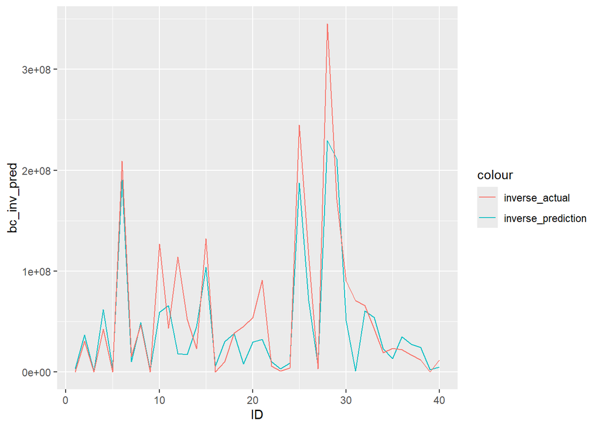

```r
df %>%  mutate(ID = 1:nrow(df)) %>%  ggplot(aes(ID)) +
  geom_line(aes(y = bc_inv_pred, colour = "inverse_prediction")) +
  geom_line(aes(y = bc_inv_act, colour = "inverse_actual"))
```

```r
data[68, 'Gross']
```

```
## # A tibble: 1 × 1
##   Gross
##   <dbl>
## 1  8300
```

Shapiro-test for error’s distribution (check if its distribution is Normal distribution or not)

```r
shapiro.test(residuals(model_re_2))
```

```
##
##  Shapiro-Wilk normality test
##
## data:  residuals(model_re_2)
## W = 0.98337, p-value = 0.03414
```

Hypothesis: H0: e is normal distribution H1: e is not normal distribution With p-value = 0.034, we will accept H0 if anpha < 0.03.

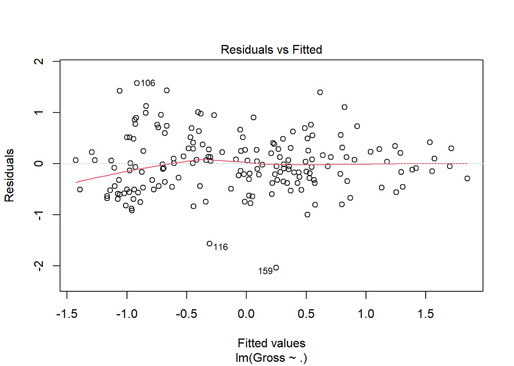

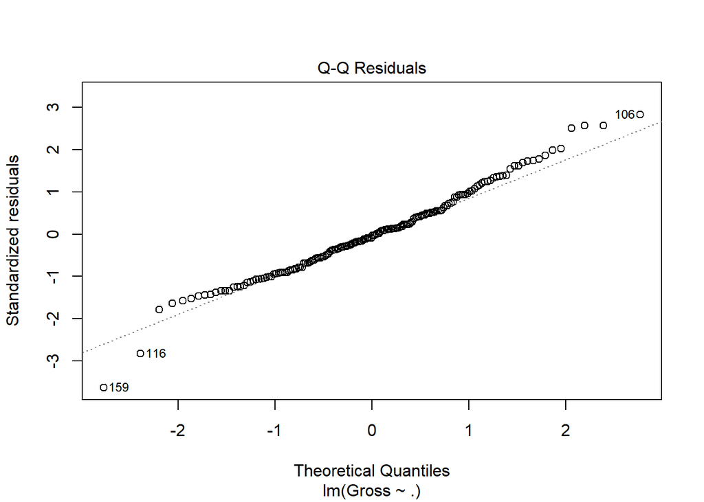

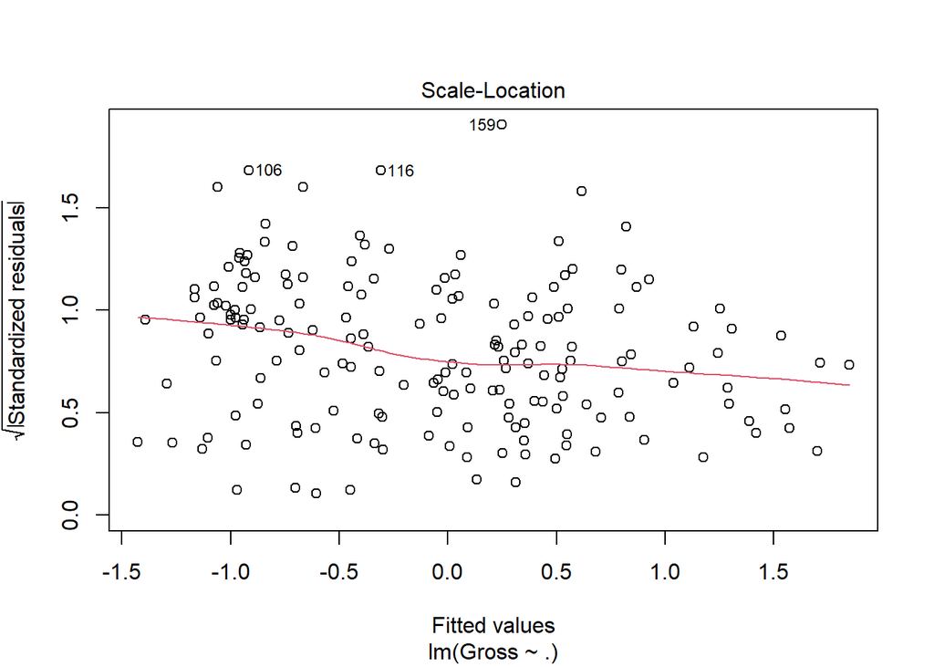

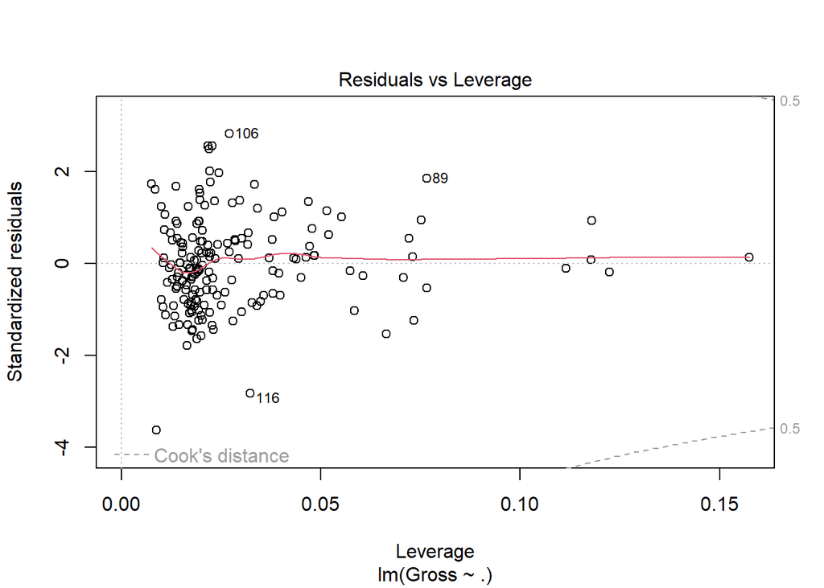

```r
plot(model_re_2)
```